# Лабораторная работа 5. Основы анализа данных NumPy и Matplotlib.

# Часть 1. NumPy

При решении научных задач с помощью численных методов зачастую приходится иметь дело с большими массивами данных в виде массивов и матриц. Стандартные средства Python (например, использование списков для хранения данных и прямой перебор элементов с помощью циклов) плохо подходят для таких задач, так как будут работать крайне медленно, в отличие от программ на компилируемых языках (Fortran, С). Пакет NumPy (http://www.numpy.org/) — это основной пакет, исполь¬зуемый в научных вычислениях в Python. NumPy предназначен для эф¬фективной работы с многомерными массивами, в том числе для эффек¬тивного применения математических операций к массивам и матрицам и их модификации без прямого перечисления элементов массивов. Поми¬мо этого NumPy обладает и другими возможностями — линейная алгеб¬ра, удобный ввод/вывод в файлы, моделирование случайных величин, быстрое преобразование Фурье, объединение программ на Fortran и С и другое (подробнее см. оф. сайт), поэтому важно изучить возможно¬сти данной библиотеки как можно лучше.

1. Внимательно изучите следующий урок по NumPy: http://scipy.github.io/old-wiki/pages/Tentative_NumPy_Tutorial.
2. Изучите официальное руководство пользователя https://docs.scipy.org/doc/numpy/user/.
3. Внимательно изучите Reference Guide (полное описание всех функ¬ций) https://docs.scipy.org/doc/numpy/reference/, именно в нем перечислены все возможности NumPy, этой ссылкой придется регу¬лярно пользоваться.

Выполните следующие задания (их много, но каждое занимает одну или несколько строк) средствами NumPy (и без использования циклов!)

Импортируйте пакет numpy под именем nр

```python
import numpy as np
```

Импортируйте пакет numpy под именем пр

```python
import numpy as пр
```

Создайте вектор из 10 элементов, заполненный 0, пятый эле-мент которого равен 1.

```python
Z = np.zeros(10)
Z[4] = 1
print(Z)
```

```
[0. 0. 0. 0. 1. 0. 0. 0. 0. 0.]
```

Создайте вектор из 10 элементов, заполненный 0, пятый эле-мент которого равен 1.

```python
Z = np.zeros(10)
Z[4] = 1
print(Z)
```

```
[0. 0. 0. 0. 1. 0. 0. 0. 0. 0.]
```

Создайте матрицу 3 на 3 со значениями от 0 до 8.

```python
matrix = np.arange(9).reshape(3, 3)
print(matrix)
```

```
[[0 1 2]
 [3 4 5]
 [6 7 8]]
```

Найдите индексы ненулевых элементов вектора [1,2,0,0,4,0].

```python
nz = np.nonzero([1,2,0,0,4,0])
print(nz)
```

```
(array([0, 1, 4]),)
```

Объявите единичную матрицу размером 3 на 3.

```python
matrix = np.eye(3)
print(matrix)
```

```
[[1. 0. 0.]
 [0. 1. 0.]
 [0. 0. 1.]]
```

Создайте массив 10x10x10 из случайных чисел.

```python
arr = np.random.random((10,10,10))
print(arr)
```

[output not shown]

[output cut: 254 more lines]

[output not shown]

Создайте матрицу 8 на 8, заполненную 0 и 1 в шахматном порядке.

```python
matrix = np.tile(np.array([[0,1],[1,0]]), (4,4))
print(matrix)
```

```
[[0 1 0 1 0 1 0 1]
 [1 0 1 0 1 0 1 0]
 [0 1 0 1 0 1 0 1]
 [1 0 1 0 1 0 1 0]
 [0 1 0 1 0 1 0 1]
 [1 0 1 0 1 0 1 0]
 [0 1 0 1 0 1 0 1]
 [1 0 1 0 1 0 1 0]]
```

Найдите произведение матриц 5x3 на 3x2 (см. линейную ал-гебру) .

```python
matrix = np.dot(np.ones((5,3)), np.ones((3,2)))
print(matrix)
```

```
[[3. 3.]
 [3. 3.]
 [3. 3.]
 [3. 3.]
 [3. 3.]]
```

Создайте матрицу, в каждом ряду которой стоят числа от 0 до 8 (используйте сложение матрицы с вектором).

```python
matrix = np.zeros((9,9))
Z = np.arange(9)
print(Z)
matrix += Z
print(matrix)
```

```
[0 1 2 3 4 5 6 7 8]
[[0. 1. 2. 3. 4. 5. 6. 7. 8.]
 [0. 1. 2. 3. 4. 5. 6. 7. 8.]
 [0. 1. 2. 3. 4. 5. 6. 7. 8.]
 [0. 1. 2. 3. 4. 5. 6. 7. 8.]
 [0. 1. 2. 3. 4. 5. 6. 7. 8.]
 [0. 1. 2. 3. 4. 5. 6. 7. 8.]
 [0. 1. 2. 3. 4. 5. 6. 7. 8.]
 [0. 1. 2. 3. 4. 5. 6. 7. 8.]
 [0. 1. 2. 3. 4. 5. 6. 7. 8.]]
```

Создайте вектор длины 1000. Найдите среднее (арифметиче¬ское) значение из этих элементов.

```python
Z = np.random.random(1000)
print(Z)
m = Z.mean()
print(m)
```

[output not shown]

[output cut: 113 more lines]

```
 0.65025345 0.11673051 0.43376867 0.79278523 0.34514613 0.34289517
 0.99964514 0.02181435 0.8303992  0.90048627 0.90858054 0.21836776
 0.70843012 0.16786357 0.57668833 0.59008126 0.69088251 0.17397961
 0.00455231 0.42842069 0.72527147 0.33071624 0.23668942 0.75042429
 0.8811646  0.81763645 0.26532168 0.39420162 0.31258406 0.98301128
 0.46970388 0.4739277  0.46953166 0.37118936 0.93856836 0.74961456
 0.38422862 0.33682569 0.00121178 0.80015259 0.48792503 0.43037678
 0.27099456 0.02685117 0.98875344 0.16649784 0.66602455 0.29104993
 0.15769146 0.26193218 0.04010113 0.86157587 0.07223333 0.47831209
 0.47302348 0.05257071 0.80899472 0.51355373 0.59457232 0.13321033
 0.07437409 0.97210454 0.60823829 0.58993595 0.86573041 0.08579248
 0.04813942 0.49998735 0.68956042 0.50539266 0.8160684  0.60970725
 0.19080775 0.17172064 0.49079414 0.12913246 0.23966872 0.41785901
 0.43260568 0.1020911  0.76749667 0.14386853]
0.48908055133579126
```

## Часть 2. Matplotlib

Matplotlib (http://matplotlib.org/index.html) — это библиотека для создания графиков в Python. Matplotlib позволяет строить графики любой сложности типографского качества, которые можно вставить в статью. Подробнее о возможностях см. http://matplotlib.org/users/ intro.html. Matplotlib — большой и сложный инструмент, но на прак¬тике в научных вычислениях часто пользуются частью библиотеки matplotlib .pyplot, которая имитирует построение графиков в стиле MATLAB. В качестве до¬статочно полного введения можно прочитать http://matplotlib.org/users/index.html.

На практике бывает очень трудно помнить все возможности Matplotlib, поэтому часто используют галереи готовых примеров, а потом модифи-цируют их под свои нужды. Примеры таких подборок можно найти по следующим ссылкам: • http://matplotlib.org/gallery.html • http://matplotlib.org/examples/index.html • http://wiki.scipy.org/Cookbook/Matplotlib/

Еще материалы.

1. Введение http://matplotlib.org/users/pyplot_tutorial.html
2. Введение 2 http://www.loria.fr/~rougier/teaching/matplotlib/. Изучите, как создавать графики разных типов http://www.loria. fr/~rougier/teaching/matplotlib/#other-types-of-plots.
3. Использование текста в подписях и т.д. http://matplotlib.org/ users/text_intro.html.
4. Использование математического текста http: //matplotlib. org/users/ mathtext.html.
5. Создание легенды http://matplotlib.org/users/legend_guide.html.
6. Интерактивное использование Matplotlib http: //matplotlib. org/ users/shell .html (этот пример можно использовать не только в командной строке, но и в коде для наблюдения за изменением гра¬фиков в ходе выполнения программы).

Постройте поточечный график функции. Сгенерируйте два массива для этого. Один со значениями по возрастанию (для X), второй со случайными значениями (для Y).

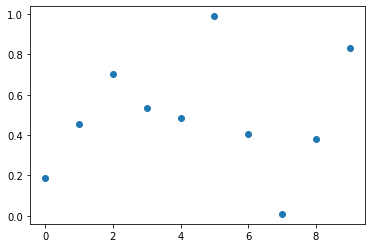

```python
import math
import matplotlib.pyplot as plt
%matplotlib inline

x = np.arange(10)
y = np.random.random(10)

print(plt.plot(x, y, 'o'))
```

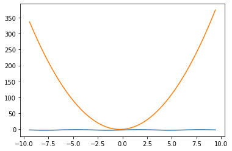

```python
x = np.linspace(-3*np.pi, 3*np.pi, 200)
T = np.sin(x) - 2
P = 2*x + 4*x*x
fig, ax = plt.subplots()
ax.plot(x, T)
ax.plot(x, P)
plt.show()
```

К графику добавьте: обозначение оси абсцисс, обозначение оси ординат, название графика, вставка легенды (текста в label).

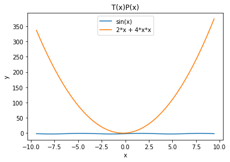

```python
x = np.linspace(-3*np.pi, 3*np.pi, 200)
T = np.sin(x) - 2
P = 2*x + 4*x*x
fig, ax = plt.subplots()
ax.plot(x, T, label = "sin(x)")
ax.plot(x, P, label = "2*x + 4*x*x")
plt.title("T(x)P(x)")
plt.xlabel("x")
plt.ylabel("y")
ax.legend()
```

Измените цвет графика на Ваш любимый.

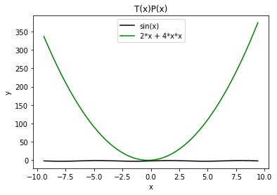

```python
x = np.linspace(-3*np.pi, 3*np.pi, 200)
T = np.sin(x) - 2
P = 2*x + 4*x*x
fig, ax = plt.subplots()
ax.plot(x, T, label = "sin(x)", color = "k")
ax.plot(x, P, label = "2*x + 4*x*x", color = "g")
plt.title("T(x)P(x)")
plt.xlabel("x")
plt.ylabel("y")
ax.legend()
```

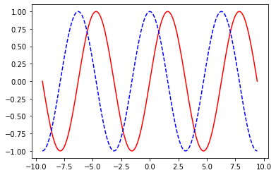

```python
x = np.linspace(-3*np.pi, 3*np.pi, 200)
T = np.sin(x)
P = np.cos(x)
fig, ax = plt.subplots()
ax.plot(x, T, color = "r", linestyle = "-")
ax.plot(x, P, color = "b", linestyle = "--")
```

Постройте теже графики, только для первого добавьте маркеры из красных треугольников, для второго синие круглые маркеры.

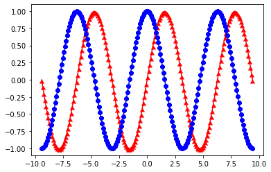

```python
x = np.linspace(-3*np.pi, 3*np.pi, 200)
T = np.sin(x)
P = np.cos(x)
fig, ax = plt.subplots()
ax.plot(x, T, color = "r", marker = 6)
ax.plot(x, P, color = "b", marker = "8")
```

Запрограмируйте сохранение графика.

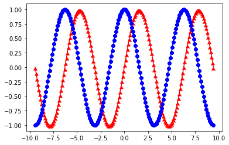

```python
x = np.linspace(-3*np.pi, 3*np.pi, 200)
T = np.sin(x)
P = np.cos(x)
fig, ax = plt.subplots()
ax.plot(x, T, color = "r", marker = 6)
ax.plot(x, P, color = "b", marker = "8")
fig.savefig('график')
```

# Часть 3. OpenCV

Прочитайте картинку используя opencv

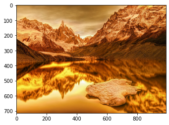

```python
import cv2
import matplotlib.pyplot as plt
image = cv2.imread('image.jpg')
plt.imshow(image)
```

Сделайте ее черно-белой

[figure not shown]

```python
gray_img = cv2.cvtColor(image, cv2.COLOR_BGR2GRAY)
#image = cv2.imread('image.jpg',1)
#gray_image = cv2.cvtColor(image, cv2.COLOR_BGR2GRAY)
plt.imshow(gray_image)
```

Измените размер на 300x300

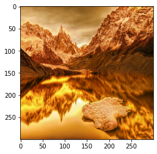

```python
img = cv2.resize(image, (300, 300))
plt.imshow(img)
```

Разбейте ее на 2 картинки. Сохраните.

```python
(h, w) = image.shape[:2]
left = image[:h, :w//2]
right = image[:h, w//2:]
cv2.imwrite('flip1.png', left)
cv2.imwrite('flip2.png', right)
```

```
True
```

Прочитайте 2 картинки и склейте.

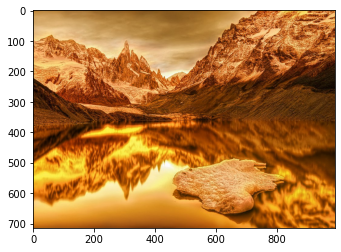

```python
img1 = cv2.imread('flip1.png',1)
img2 = cv2.imread('flip2.png',1)
vis = np.concatenate((img1, img2), axis=1)
plt.imshow(vis)
```